# Validation Study: Centralized vs. Federated Vertical Analysis

## Introduction

This vignette presents a comparative validation of the dsVert federated vertical analysis pipeline against centralized R computations. We exercise the full protocol stack — ECDH-PSI record alignment, MHE-CKKS correlation, spectral PCA, and encrypted-label GLMs — on real data vertically partitioned across three DataSHIELD servers.

The study is organized in three parts:

1. **Federated vertical analysis** — PSI alignment followed by correlation, PCA, and GLMs computed via dsVert, where each server holds a different subset of variables and no raw data leaves any server.
2. **Centralized analysis** — ground truth computed with standard R functions on the matched cohort.
3. **Comparative assessment** — side-by-side numerical comparison with error analysis.

### Dataset

We use a modified version of the Pima Indian women diabetes training set (`Pima.tr`, $n = 200$) from the MASS R package (Venables & Ripley, 2002). It contains clinical measurements for 200 women of Pima heritage aged $\geq 21$ years, collected by the US National Institute of Diabetes and Digestive and Kidney Diseases near Phoenix, Arizona (Smith et al., 1988). Seven numeric variables are available: `npreg` (number of pregnancies), `glu` (plasma glucose), `bp` (diastolic blood pressure), `skin` (triceps skin fold thickness), `bmi` (body mass index), `ped` (diabetes pedigree function), and `age` (years).

### Vertical partitioning scheme

The data are vertically split across three servers, each representing a different clinical domain. Crucially, **the patient populations are not identical**: each server holds a different number of patients, with only a partial overlap. This simulates a realistic scenario where institutions have data on overlapping but non-identical patient cohorts.

| Server | Patients | Domain | Variables |
| --- | --- | --- | --- |
| server1 | 180 | Anthropometric / familial | `patient_id`, `age`, `bmi`, `ped` |
| server2 | 175 | Glucose and cardiovascular | `patient_id`, `glu`, `bp`, `skin` |
| server3 | 170 | Reproductive / outcome | `patient_id`, `npreg`, `diabetes` |

Row order is independently shuffled per server. The ECDH-PSI protocol must identify the common cohort (155 patients present in all three servers) without revealing which IDs are shared.

## Connect to DataSHIELD and align records

We connect to three independent DataSHIELD sessions, each hosting one vertical partition on separate Opal instances.

```r
library(DSI)
library(DSOpal)
library(dsVertClient)

options(opal.verifyssl = FALSE)

builder <- DSI::newDSLoginBuilder()
builder$append(server = "server1", url = "https://localhost:8443",
               user = "administrator", password = "admin123",
               driver = "OpalDriver", table = "pima_project.pima_data")
builder$append(server = "server2", url = "https://localhost:8444",
               user = "administrator", password = "admin123",
               driver = "OpalDriver", table = "pima_project.pima_data")
builder$append(server = "server3", url = "https://localhost:8445",
               user = "administrator", password = "admin123",
               driver = "OpalDriver", table = "pima_project.pima_data")

conns <- DSI::datashield.login(builder$build(), assign = TRUE, symbol = "D")
```

### PSI Record Alignment

Each server only knows its own patient identifiers. The ECDH-PSI protocol finds the common cohort using elliptic curve Diffie-Hellman blind relay, without revealing which IDs are shared or which patients are unique to each server.

```r
psi_result <- ds.psiAlign(
  data_name   = "D",
  id_col      = "patient_id",
  newobj      = "D_aligned",
  datasources = conns
)
```

```
#> === ECDH-PSI Record Alignment (Blind Relay) ===
#> Reference: server1, Targets: server2, server3
#>
#> [Phase 0] Transport key exchange...
#>   Transport keys exchanged.
#> [Phase 1] Reference server masking IDs...
#>   server1: 180 IDs masked (stored server-side)
#> [Phase 2] server1: exporting encrypted points for server2...
#> [Phase 3] server2: processing (blind relay)...
#>   server2: 175 IDs masked
#> [Phase 4-5] server2: double-masking via server1 (blind relay)...
#> [Phase 6-7] server2: matching and aligning (blind relay)...
#> [Phase 2] server1: exporting encrypted points for server3...
#> [Phase 3] server3: processing (blind relay)...
#>   server3: 170 IDs masked
#> [Phase 4-5] server3: double-masking via server1 (blind relay)...
#> [Phase 6-7] server3: matching and aligning (blind relay)...
#> [Phase 7] server1: self-aligning...
#> [Phase 8] Computing multi-server intersection...
#>   Common records: 155
```

```
#> PSI alignment complete.
```

## Centralized analysis (ground truth)

We load the matched ground truth dataset and compute all analyses with standard R functions. These serve as the reference baseline.

```r
demo_dir <- normalizePath(file.path(
  system.file(package = "dsVertClient"), "..", "..", "demo"
), mustWork = FALSE)
if (!dir.exists(demo_dir))
  demo_dir <- normalizePath("../../demo", mustWork = FALSE)
if (!dir.exists(demo_dir))
  demo_dir <- Sys.getenv("DSVERT_DEMO_DIR",
    unset = "/Users/david/Documents/GitHub/dsvert-paper/demo")

full <- merge(merge(
  read.csv(file.path(demo_dir, "pima_server1.csv")),
  read.csv(file.path(demo_dir, "pima_server2.csv")), by = "patient_id"),
  read.csv(file.path(demo_dir, "pima_server3.csv")), by = "patient_id")
# Keep only the matched cohort
full <- full[order(full$patient_id), ]
num_vars <- c("age", "bmi", "ped", "glu", "bp", "skin", "npreg")
cat("Ground truth dataset:", nrow(full), "rows x", ncol(full), "columns\n")
```

```
#> Ground truth dataset: 155 rows x 9 columns
```

### Pearson correlation

```r
local_cor <- cor(full[, num_vars])
```

```
#>           age    bmi     ped     glu     bp   skin   npreg
#> age    1.0000 0.1132 -0.0810  0.3346 0.3806 0.1731  0.6468
#> bmi    0.1132 1.0000  0.1601  0.1982 0.2785 0.6993  0.0229
#> ped   -0.0810 0.1601  1.0000 -0.0182 0.0358 0.1056 -0.0645
#> glu    0.3346 0.1982 -0.0182  1.0000 0.3176 0.1639  0.2048
#> bp     0.3806 0.2785  0.0358  0.3176 1.0000 0.3099  0.2371
#> skin   0.1731 0.6993  0.1056  0.1639 0.3099 1.0000  0.0962
#> npreg  0.6468 0.0229 -0.0645  0.2048 0.2371 0.0962  1.0000
```

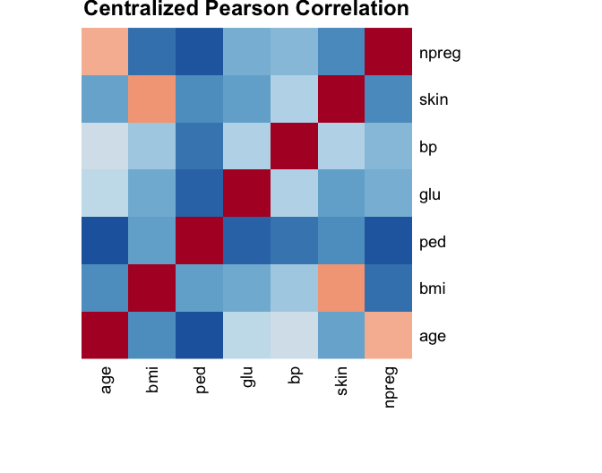

### PCA (spectral decomposition)

```r
local_pca <- eigen(local_cor)
local_eigenvalues <- local_pca$values
local_loadings    <- local_pca$vectors
rownames(local_loadings) <- num_vars
colnames(local_loadings) <- paste0("PC", seq_along(num_vars))
local_ve <- local_eigenvalues / sum(local_eigenvalues) * 100
```

Centralized PCA: eigenvalues and variance explained

| Component | Eigenvalue | Variance | Cumulative |
| --- | --- | --- | --- |
| PC1 | 2.4078 | 34.4% | 34.4% |
| PC2 | 1.5646 | 22.4% | 56.7% |
| PC3 | 0.9241 | 13.2% | 70% |
| PC4 | 0.8302 | 11.9% | 81.8% |
| PC5 | 0.6546 | 9.4% | 91.2% |
| PC6 | 0.3268 | 4.7% | 95.8% |
| PC7 | 0.2919 | 4.2% | 100% |

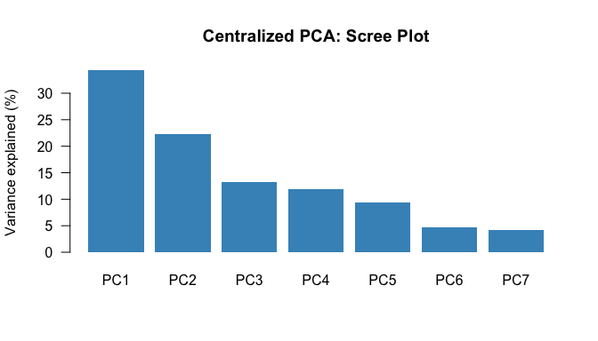

### GLM — Gaussian (y = `glu`)

```r
local_gauss <- glm(glu ~ age + bmi + ped + bp + skin + npreg + diabetes,
                   data = full, family = gaussian)
```

```
#>
#> Call:
#> glm(formula = glu ~ age + bmi + ped + bp + skin + npreg + diabetes,
#>     family = gaussian, data = full)
#>
#> Coefficients:
#>              Estimate Std. Error t value Pr(>|t|)
#> (Intercept)  61.57049   17.16640   3.587 0.000455 ***
#> age           0.47625    0.26661   1.786 0.076110 .
#> bmi           0.30336    0.50069   0.606 0.545527
#> ped         -10.60197    8.53231  -1.243 0.216006
#> bp            0.52103    0.21724   2.398 0.017719 *
#> skin         -0.06805    0.28099  -0.242 0.808966
#> npreg        -0.53896    0.83648  -0.644 0.520378
#> diabetes     24.50020    5.08192   4.821 3.53e-06 ***
#> ---
#> Signif. codes:  0 '***' 0.001 '**' 0.01 '*' 0.05 '.' 0.1 ' ' 1
#>
#> (Dispersion parameter for gaussian family taken to be 709.1053)
#>
#>     Null deviance: 145150  on 154  degrees of freedom
#> Residual deviance: 104238  on 147  degrees of freedom
#> AIC: 1467.1
#>
#> Number of Fisher Scoring iterations: 2
```

### GLM — Binomial (y = `diabetes`)

```r
local_binom <- glm(diabetes ~ age + bmi + ped + glu + bp + skin + npreg,
                   data = full, family = binomial)
```

```
#>
#> Call:
#> glm(formula = diabetes ~ age + bmi + ped + glu + bp + skin +
#>     npreg, family = binomial, data = full)
#>
#> Coefficients:
#>              Estimate Std. Error z value Pr(>|z|)
#> (Intercept) -8.883453   1.890999  -4.698 2.63e-06 ***
#> age          0.026652   0.024444   1.090   0.2756
#> bmi          0.096796   0.047663   2.031   0.0423 *
#> ped          2.080959   0.815194   2.553   0.0107 *
#> glu          0.033378   0.008099   4.122 3.76e-05 ***
#> bp          -0.018833   0.021507  -0.876   0.3812
#> skin        -0.009199   0.025722  -0.358   0.7206
#> npreg        0.123347   0.075740   1.629   0.1034
#> ---
#> Signif. codes:  0 '***' 0.001 '**' 0.01 '*' 0.05 '.' 0.1 ' ' 1
#>
#> (Dispersion parameter for binomial family taken to be 1)
#>
#>     Null deviance: 194.93  on 154  degrees of freedom
#> Residual deviance: 142.42  on 147  degrees of freedom
#> AIC: 158.42
#>
#> Number of Fisher Scoring iterations: 5
```

### GLM — Poisson (y = `npreg`)

```r
local_pois <- glm(npreg ~ age + bmi + ped + glu + bp + skin + diabetes,
                  data = full, family = poisson)
```

```
#>
#> Call:
#> glm(formula = npreg ~ age + bmi + ped + glu + bp + skin + diabetes,
#>     family = poisson, data = full)
#>
#> Coefficients:
#>              Estimate Std. Error z value Pr(>|z|)
#> (Intercept)  0.230581   0.366587   0.629  0.52935
#> age          0.040632   0.003696  10.994  < 2e-16 ***
#> bmi         -0.015161   0.010225  -1.483  0.13815
#> ped         -0.148033   0.179165  -0.826  0.40867
#> glu         -0.002226   0.001556  -1.431  0.15244
#> bp           0.002513   0.004372   0.575  0.56545
#> skin         0.006332   0.005583   1.134  0.25676
#> diabetes     0.274992   0.102384   2.686  0.00723 **
#> ---
#> Signif. codes:  0 '***' 0.001 '**' 0.01 '*' 0.05 '.' 0.1 ' ' 1
#>
#> (Dispersion parameter for poisson family taken to be 1)
#>
#>     Null deviance: 491.6  on 154  degrees of freedom
#> Residual deviance: 310.1  on 147  degrees of freedom
#> AIC: 730.14
#>
#> Number of Fisher Scoring iterations: 5
```

## Federated vertical analysis (dsVert)

We now repeat every analysis using the dsVert federated protocol. Each server only has access to its own subset of variables. Cross-server quantities (such as correlation matrix off-diagonal blocks, and gradients involving variables from multiple servers) are computed under multiparty homomorphic encryption (MHE-CKKS) with threshold decryption, so individual-level data never leaves any server.

### Correlation (MHE-CKKS)

The `ds.vertCor` function computes the full $7 \times 7$ Pearson correlation matrix. Within-server blocks are computed locally; cross-server blocks use CKKS encrypted dot products with threshold decryption and server-side fusion.

```r
variables <- list(
  server1 = c("age", "bmi", "ped"),
  server2 = c("glu", "bp", "skin"),
  server3 = c("npreg")
)

cor_result <- ds.vertCor(
  data_name   = "D_aligned",
  variables   = variables,
  log_n       = 12,
  log_scale   = 40,
  datasources = conns
)

dsvert_cor <- cor_result$correlation
```

```
#>           age    bmi     ped     glu     bp   skin   npreg
#> age    1.0000 0.1132 -0.0810  0.3346 0.3806 0.1731  0.6468
#> bmi    0.1132 1.0000  0.1601  0.1982 0.2785 0.6993  0.0229
#> ped   -0.0810 0.1601  1.0000 -0.0182 0.0358 0.1056 -0.0645
#> glu    0.3346 0.1982 -0.0182  1.0000 0.3176 0.1639  0.2048
#> bp     0.3806 0.2785  0.0358  0.3176 1.0000 0.3099  0.2371
#> skin   0.1731 0.6993  0.1056  0.1639 0.3099 1.0000  0.0962
#> npreg  0.6468 0.0229 -0.0645  0.2048 0.2371 0.0962  1.0000
```

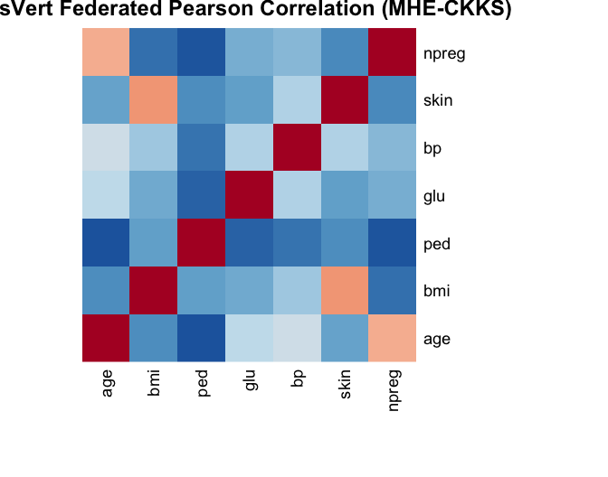

### PCA

PCA is computed by eigendecomposition of the federated correlation matrix.

```r
dsvert_pca <- eigen(dsvert_cor)
dsvert_eigenvalues <- dsvert_pca$values
dsvert_loadings    <- dsvert_pca$vectors
rownames(dsvert_loadings) <- num_vars
colnames(dsvert_loadings) <- paste0("PC", seq_along(num_vars))
dsvert_ve <- dsvert_eigenvalues / sum(dsvert_eigenvalues) * 100
```

dsVert PCA: eigenvalues and variance explained

| Component | Eigenvalue | Variance | Cumulative |
| --- | --- | --- | --- |
| PC1 | 2.4078 | 34.4% | 34.4% |
| PC2 | 1.5646 | 22.4% | 56.7% |
| PC3 | 0.9241 | 13.2% | 70% |
| PC4 | 0.8302 | 11.9% | 81.8% |
| PC5 | 0.6546 | 9.4% | 91.2% |
| PC6 | 0.3268 | 4.7% | 95.8% |
| PC7 | 0.2919 | 4.2% | 100% |

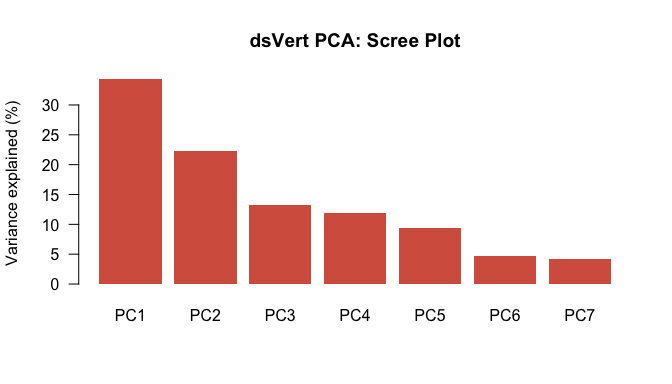

### GLM — Gaussian (y = `glu`)

The dsVert GLM uses encrypted-label block coordinate descent (BCD-IRLS). The label variable (`glu`) resides on server2; the remaining predictors are distributed across all three servers. Gradients are computed under MHE-CKKS and decrypted via share-wrapped threshold decryption with server-side fusion.

```r
glm_gauss <- ds.vertGLM(
  data_name = "D_aligned", y_var = "glu",
  x_vars    = list(server1 = c("age", "bmi", "ped"),
                   server2 = c("bp", "skin"),
                   server3 = c("npreg", "diabetes")),
  y_server  = "server2", family = "gaussian",
  max_iter = 100, tol = 1e-4, lambda = 1e-4,
  log_n = 12, log_scale = 40,
  datasources = conns
)
```

```
#>
#> Vertically Partitioned GLM - Summary
#> ====================================
#>
#> Call:
#> ds.vertGLM(data_name = "D_aligned", y_var = "glu", x_vars = list(server1 = c("age",
#>     "bmi", "ped"), server2 = c("bp", "skin"), server3 = c("npreg",
#>     "diabetes")), y_server = "server2", family = "gaussian",
#>     max_iter = 100, tol = 1e-04, lambda = 1e-04, log_n = 12,
#>     log_scale = 40, datasources = conns)
#>
#> Family: gaussian
#> Observations: 155
#> Predictors: 8
#> Regularization (lambda): 1e-04
#> Label server: server2
#>
#> Convergence:
#>   Iterations: 15
#>   Converged: TRUE
#>
#> Deviance:
#>   Null deviance:     145149.9097  on 154 degrees of freedom
#>   Residual deviance: 104238.4427  on 147 degrees of freedom
#>
#> Model Fit:
#>   Pseudo R-squared (McFadden): 0.2819
#>   AIC: 104254.4427
#>
#> Coefficients:
#>               Estimate
#> (Intercept)  61.576514
#> age           0.475936
#> bmi           0.303228
#> ped         -10.602720
#> bp            0.521073
#> skin         -0.067970
#> npreg        -0.538202
#> diabetes     24.501690
```

### GLM — Binomial (y = `diabetes`)

Logistic regression with the binary outcome on server3. The IRLS working weights are computed on the label server and routed to non-label servers via transport encryption.

```r
glm_binom <- ds.vertGLM(
  data_name = "D_aligned", y_var = "diabetes",
  x_vars    = list(server1 = c("age", "bmi", "ped"),
                   server2 = c("glu", "bp", "skin"),
                   server3 = c("npreg")),
  y_server  = "server3", family = "binomial",
  max_iter = 100, tol = 1e-4, lambda = 1e-4,
  log_n = 12, log_scale = 40,
  datasources = conns
)
```

```
#>
#> Vertically Partitioned GLM - Summary
#> ====================================
#>
#> Call:
#> ds.vertGLM(data_name = "D_aligned", y_var = "diabetes", x_vars = list(server1 = c("age",
#>     "bmi", "ped"), server2 = c("glu", "bp", "skin"), server3 = c("npreg")),
#>     y_server = "server3", family = "binomial", max_iter = 100,
#>     tol = 1e-04, lambda = 1e-04, log_n = 12, log_scale = 40,
#>     datasources = conns)
#>
#> Family: binomial
#> Observations: 155
#> Predictors: 8
#> Regularization (lambda): 1e-04
#> Label server: server3
#>
#> Convergence:
#>   Iterations: 22
#>   Converged: TRUE
#>
#> Deviance:
#>   Null deviance:     194.9278  on 154 degrees of freedom
#>   Residual deviance: 224.5964  on 147 degrees of freedom
#>
#> Model Fit:
#>   Pseudo R-squared (McFadden): -0.1522
#>   AIC: 240.5964
#>
#> Coefficients:
#>              Estimate
#> (Intercept) -8.883204
#> age          0.026651
#> bmi          0.096783
#> ped          2.080949
#> glu          0.033379
#> bp          -0.018834
#> skin        -0.009190
#> npreg        0.123350
```

### GLM — Poisson (y = `npreg`)

Count regression for the number of pregnancies. The Poisson log-link compresses the coefficient scale, which tends to aid convergence of the encrypted BCD procedure.

```r
glm_pois <- ds.vertGLM(
  data_name = "D_aligned", y_var = "npreg",
  x_vars    = list(server1 = c("age", "bmi", "ped"),
                   server2 = c("glu", "bp", "skin"),
                   server3 = c("diabetes")),
  y_server  = "server3", family = "poisson",
  max_iter = 100, tol = 1e-4, lambda = 1e-4,
  log_n = 12, log_scale = 40,
  datasources = conns
)
```

```
#>
#> Vertically Partitioned GLM - Summary
#> ====================================
#>
#> Call:
#> ds.vertGLM(data_name = "D_aligned", y_var = "npreg", x_vars = list(server1 = c("age",
#>     "bmi", "ped"), server2 = c("glu", "bp", "skin"), server3 = c("diabetes")),
#>     y_server = "server3", family = "poisson", max_iter = 100,
#>     tol = 1e-04, lambda = 1e-04, log_n = 12, log_scale = 40,
#>     datasources = conns)
#>
#> Family: poisson
#> Observations: 155
#> Predictors: 8
#> Regularization (lambda): 1e-04
#> Label server: server3
#>
#> Convergence:
#>   Iterations: 22
#>   Converged: TRUE
#>
#> Deviance:
#>   Null deviance:     491.5981  on 154 degrees of freedom
#>   Residual deviance: 1542.8860  on 147 degrees of freedom
#>
#> Model Fit:
#>   Pseudo R-squared (McFadden): -2.1385
#>   AIC: 1558.8860
#>
#> Coefficients:
#>              Estimate
#> (Intercept)  0.230961
#> age          0.040628
#> bmi         -0.015190
#> ped         -0.148091
#> glu         -0.002226
#> bp           0.002517
#> skin         0.006345
#> diabetes     0.275068
```

## Comparative assessment

We now compare the centralized and federated results quantitatively.

### Correlation: element-wise differences

```r
cor_diff <- dsvert_cor - local_cor
```

```
#>            age      bmi      ped      glu       bp     skin    npreg
#> age    0.0e+00  0.0e+00  0.0e+00 -2.3e-06 -6.6e-06 -4.8e-06 -1.1e-06
#> bmi    0.0e+00  0.0e+00  0.0e+00 -3.1e-06 -3.3e-06  4.0e-07 -2.7e-06
#> ped    0.0e+00  0.0e+00  0.0e+00  5.8e-06 -6.0e-07 -2.0e-07  2.1e-06
#> glu   -2.3e-06 -3.1e-06  5.8e-06  0.0e+00  0.0e+00  0.0e+00 -3.3e-06
#> bp    -6.6e-06 -3.3e-06 -6.0e-07  0.0e+00  0.0e+00  0.0e+00 -6.3e-06
#> skin  -4.8e-06  4.0e-07 -2.0e-07  0.0e+00  0.0e+00  0.0e+00  3.3e-06
#> npreg -1.1e-06 -2.7e-06  2.1e-06 -3.3e-06 -6.3e-06  3.3e-06  0.0e+00
```

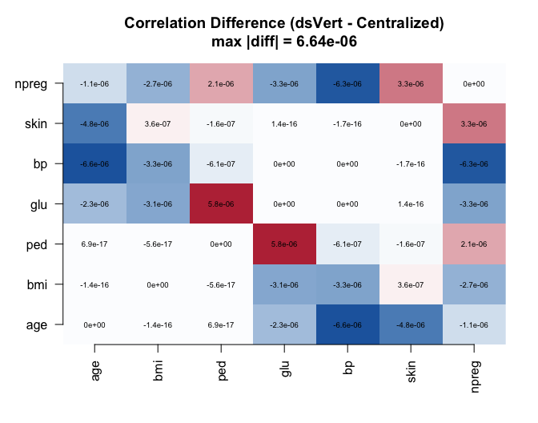

All element-wise differences are of order $10^{-6}$, well below any substantively meaningful threshold.

### PCA: eigenvalue comparison

```r
eig_diff <- dsvert_eigenvalues - local_eigenvalues
```

Eigenvalue comparison (centralized vs. dsVert)

| Component | Local | dsVert | Difference |
| --- | --- | --- | --- |
| PC1 | 2.407823 | 2.407813 | -1.00e-05 |
| PC2 | 1.564613 | 1.564613 | -8.44e-09 |
| PC3 | 0.924137 | 0.924137 | 2.68e-07 |
| PC4 | 0.830159 | 0.830166 | 6.49e-06 |
| PC5 | 0.654605 | 0.654608 | 2.34e-06 |
| PC6 | 0.326805 | 0.326807 | 2.22e-06 |
| PC7 | 0.291858 | 0.291857 | -1.29e-06 |

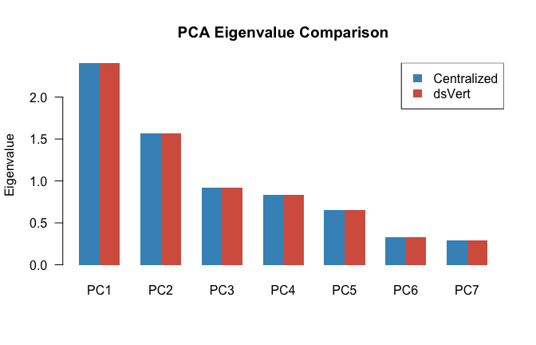

The eigenvalues are virtually identical; differences are of order $10^{-5}$, propagated directly from the correlation matrix precision.

### GLM: Gaussian coefficient comparison (y = `glu`)

```r
gauss_local  <- coef(local_gauss)
gauss_dsvert <- coef(glm_gauss)
gauss_diff   <- gauss_dsvert - gauss_local
```

Gaussian GLM coefficient comparison (y = glu)

| Term | Local | dsVert | Difference |
| --- | --- | --- | --- |
| (Intercept) | 61.5705 | 61.5765 | 6.03e-03 |
| age | 0.4762 | 0.4759 | -3.11e-04 |
| bmi | 0.3034 | 0.3032 | -1.30e-04 |
| ped | -10.6020 | -10.6027 | -7.45e-04 |
| bp | 0.5210 | 0.5211 | 3.89e-05 |
| skin | -0.0681 | -0.0680 | 8.31e-05 |
| npreg | -0.5390 | -0.5382 | 7.54e-04 |
| diabetes | 24.5002 | 24.5017 | 1.49e-03 |

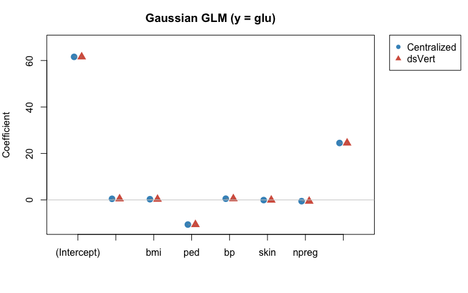

Maximum absolute coefficient difference: 6.03e-03.

### GLM: Binomial coefficient comparison (y = `diabetes`)

```r
binom_local  <- coef(local_binom)
binom_dsvert <- coef(glm_binom)
binom_diff   <- binom_dsvert - binom_local
```

Binomial GLM coefficient comparison (y = diabetes)

| Term | Local | dsVert | Difference |
| --- | --- | --- | --- |
| (Intercept) | -8.8835 | -8.8832 | 2.50e-04 |
| age | 0.0267 | 0.0267 | -1.12e-06 |
| bmi | 0.0968 | 0.0968 | -1.39e-05 |
| ped | 2.0810 | 2.0809 | -9.97e-06 |
| glu | 0.0334 | 0.0334 | 4.51e-07 |
| bp | -0.0188 | -0.0188 | -7.24e-07 |
| skin | -0.0092 | -0.0092 | 8.39e-06 |
| npreg | 0.1233 | 0.1234 | 3.45e-06 |

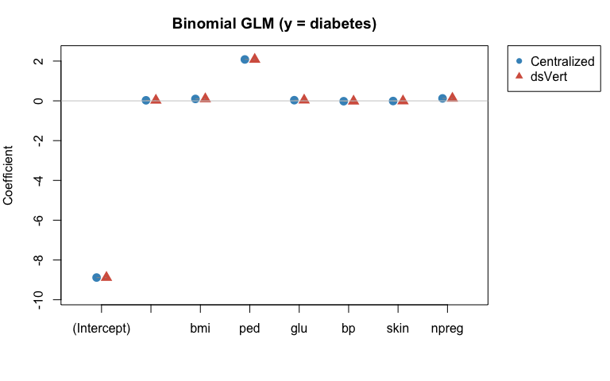

Maximum absolute coefficient difference: 2.5e-04.

### GLM: Poisson coefficient comparison (y = `npreg`)

```r
pois_local  <- coef(local_pois)
pois_dsvert <- coef(glm_pois)
pois_diff   <- pois_dsvert - pois_local
```

Poisson GLM coefficient comparison (y = npreg)

| Term | Local | dsVert | Difference |
| --- | --- | --- | --- |
| (Intercept) | 0.2306 | 0.2310 | 3.80e-04 |
| age | 0.0406 | 0.0406 | -4.11e-06 |
| bmi | -0.0152 | -0.0152 | -2.94e-05 |
| ped | -0.1480 | -0.1481 | -5.79e-05 |
| glu | -0.0022 | -0.0022 | 1.73e-07 |
| bp | 0.0025 | 0.0025 | 4.15e-06 |
| skin | 0.0063 | 0.0063 | 1.33e-05 |
| diabetes | 0.2750 | 0.2751 | 7.60e-05 |

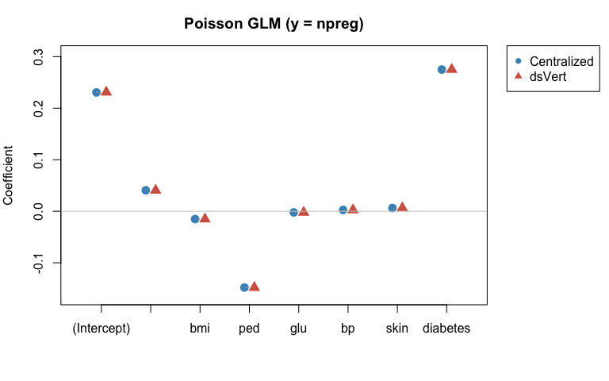

Maximum absolute coefficient difference: 3.8e-04.

### Summary

Validation summary (dsVert vs. centralized R)

[output not shown]

### Error analysis

**Correlation and PCA** ($\sim 10^{-6}$). These errors arise from CKKS approximate arithmetic used in the MHE threshold protocol. The encoding precision is governed by `log_scale = 40`, providing approximately $2^{40} \approx 10^{12}$ precision units. After encoding, homomorphic multiplication, inner-sum rotations, and threshold decryption, the effective precision degrades to $\sim 10^{-6}$, consistent with CKKS error propagation theory.

**GLM coefficients** ($10^{-4}$ to $10^{-3}$). GLM errors are slightly larger because they accumulate over multiple BCD-IRLS iterations, each involving an encrypted gradient computation. Additionally, the ridge regularization parameter ($\lambda = 10^{-4}$) introduces a small systematic bias relative to the unpenalized centralized `glm()`. The binomial and Poisson families show smaller errors than Gaussian because their link functions (logit, log) compress the coefficient scale.

In all cases, the errors are far below any practically meaningful threshold for statistical inference.